# Project 4: Wrangle and Analyze Data

In this project, i will need to gather dtata from variety of sources and in a variety of formats, assess its quality and tidiness, then clean it.

**Topic** WeRateDogs is a Twitter account that rates people's dogs with a humorous comment about the dog. These ratings almost always have a denominator of 10. The numerators almost always greater than 10. It has over 4 million followers and has received international media coverage. The goal of this project is to create interesting and trustworthy analyses and visualizatons based on the data gather from WeRateDogs.

```python
# Import libraries
import pandas as pd
import numpy as np
import requests
import os

## For section to use Tweepy library to query the Twitter API for each tweet's JSON
import tweepy
from tweepy import OAuthHandler
import json
from timeit import default_timer as timer

## Visualization
import matplotlib.pyplot as plt
import seaborn as sns
%matplotlib inline
```

# 1 Data Wrangling

This section includes the following steps:

- Gathering data
- Assessing data (detect and document at least 8 quality issues and 2 tidiness issues)
- Cleaning data

## 1.1 Gathering Data

Data collected in this project includes:

1. WeRateDogs twitter archive: twitter_archieve_enhanced.csv
2. Tweet image predictions - breed of dog: image_predictions.tsv
3. Each tweet's retweet count and favourite ("like") count at min

### 1.1.1 WeRateDogs

```python
# Read csv file into DataFrame
twitter_archive = pd.read_csv('./data/twitter-archive-enhanced.csv')
twitter_archive.head()
```

|  | tweet_id | in_reply_to_status_id | in_reply_to_user_id | timestamp | source | text | retweeted_status_id | retweeted_status_user_id | retweeted_status_timestamp | expanded_urls | rating_numerator | rating_denominator | name | doggo | floofer | pupper | puppo |
| --- | --- | --- | --- | --- | --- | --- | --- | --- | --- | --- | --- | --- | --- | --- | --- | --- | --- |
| 0 | 892420643555336193 | NaN | NaN | 2017-08-01 16:23:56 +0000 | <a href="http://twitter.com/download/iphone" r... | This is Phineas. He's a mystical boy. Only eve... | NaN | NaN | NaN | https://twitter.com/dog_rates/status/892420643... | 13 | 10 | Phineas | None | None | None | None |
| 1 | 892177421306343426 | NaN | NaN | 2017-08-01 00:17:27 +0000 | <a href="http://twitter.com/download/iphone" r... | This is Tilly. She's just checking pup on you.... | NaN | NaN | NaN | https://twitter.com/dog_rates/status/892177421... | 13 | 10 | Tilly | None | None | None | None |
| 2 | 891815181378084864 | NaN | NaN | 2017-07-31 00:18:03 +0000 | <a href="http://twitter.com/download/iphone" r... | This is Archie. He is a rare Norwegian Pouncin... | NaN | NaN | NaN | https://twitter.com/dog_rates/status/891815181... | 12 | 10 | Archie | None | None | None | None |
| 3 | 891689557279858688 | NaN | NaN | 2017-07-30 15:58:51 +0000 | <a href="http://twitter.com/download/iphone" r... | This is Darla. She commenced a snooze mid meal... | NaN | NaN | NaN | https://twitter.com/dog_rates/status/891689557... | 13 | 10 | Darla | None | None | None | None |
| 4 | 891327558926688256 | NaN | NaN | 2017-07-29 16:00:24 +0000 | <a href="http://twitter.com/download/iphone" r... | This is Franklin. He would like you to stop ca... | NaN | NaN | NaN | https://twitter.com/dog_rates/status/891327558... | 12 | 10 | Franklin | None | None | None | None |

### 1.1.2 Image of dog

The file `image_predictions.tsv`, record the prediction the breed of dog that is present in each tweet. It was hosted on Udacity's servers with the url shown in below code cell, which will be downloaded programmatically usign the `Requests` library.

```python
url = "https://d17h27t6h515a5.cloudfront.net/topher/2017/August/599fd2ad_image-predictions/image-predictions.tsv"

response = requests.get(url)
```

```python
# Open file and write contents of the response vairable to it

with open('./data/image_predictions.tsv', mode = 'wb') as file:
    file.write(response.content)
```

```python
# Check if it execute successfully
os.listdir('./data')
```

```
['twitter-archive-enhanced.csv', '.DS_Store', 'image_predictions.tsv']
```

```python
image = pd.read_csv('./data/image_predictions.tsv', sep='\t')
image.head()
```

|  | tweet_id | jpg_url | img_num | p1 | p1_conf | p1_dog | p2 | p2_conf | p2_dog | p3 | p3_conf | p3_dog |
| --- | --- | --- | --- | --- | --- | --- | --- | --- | --- | --- | --- | --- |
| 0 | 666020888022790149 | https://pbs.twimg.com/media/CT4udn0WwAA0aMy.jpg | 1 | Welsh_springer_spaniel | 0.465074 | True | collie | 0.156665 | True | Shetland_sheepdog | 0.061428 | True |
| 1 | 666029285002620928 | https://pbs.twimg.com/media/CT42GRgUYAA5iDo.jpg | 1 | redbone | 0.506826 | True | miniature_pinscher | 0.074192 | True | Rhodesian_ridgeback | 0.072010 | True |
| 2 | 666033412701032449 | https://pbs.twimg.com/media/CT4521TWwAEvMyu.jpg | 1 | German_shepherd | 0.596461 | True | malinois | 0.138584 | True | bloodhound | 0.116197 | True |
| 3 | 666044226329800704 | https://pbs.twimg.com/media/CT5Dr8HUEAA-lEu.jpg | 1 | Rhodesian_ridgeback | 0.408143 | True | redbone | 0.360687 | True | miniature_pinscher | 0.222752 | True |
| 4 | 666049248165822465 | https://pbs.twimg.com/media/CT5IQmsXIAAKY4A.jpg | 1 | miniature_pinscher | 0.560311 | True | Rottweiler | 0.243682 | True | Doberman | 0.154629 | True |

#### 1.1.3 Additional information

Additional information like tweet's retweet count and favorite ("like") count and any additional interesting data will be gather by querying the **Twitter API** with the tweet IDs from `twitter_archive` dataframe, using Python's [Tweepy](https://www.tweepy.org/) library and store each tweet's entire set of JSON data in `tweet_json.txt`. Twitter API

```python
# Install tweepy
#pip install tweepy
```

[output not shown]

```python
# API Keys, Secrets and Tokens
consumer_key = "YOUR CONSUMER KEY"
consumer_secret = "YOUR CONSUMER SECRET"
access_token = "YOUR ACCESS TOKEN"
access_secret = "YOUR ACCESS SECRET"
```

The following code, which is provided in the [Getting started](https://buildmedia.readthedocs.org/media/pdf/tweepy/latest/tweepy.pdf) portion of the Tweepy documentation, will create an API object that you can use to gather Twitter data.

```python
auth = tweepy.OAuthHandler(consumer_key, consumer_secret)
auth.set_access_token(access_token, access_secret)

api = tweepy.API(auth)
```

The `tweepy` library uses `tweepy.get_status()` to access specific tweets by their id.

```
tweet = api.get_status(id_of_tweet)
print(tweet.text)
```

Describe in [StackOverflow answer](https://stackoverflow.com/questions/28384588/twitter-api-get-tweets-with-specific-id)  
[Reading and Writing JSON to a file in python](https://stackabuse.com/reading-and-writing-json-to-a-file-in-python/)

```python
# Store the tweet_id in twetter_archive dataframe in tweet_ids
tweet_ids = twitter_archive.tweet_id.values
len(tweet_ids)
```

```
2356
```

### DO NOT run below cell code, as this notebook does not include the API keys, secret, token needed

```python
# Query Twitter's API for JSON data for each tweet ID in the Twitter archive
count = 0
fails_dict = {}
start = timer()

# Save each tweet's returned JSON as a new line in a .txt file
with open('./data/tweet_json_SAMPLE.txt', 'w') as outfile:
    # This loop will likely take 20-30 min to run
    for tweet_id in tweet_ids:
        count += 1
        print(str(count) + ": " + str(tweet_id))
        try:
            tweet = api.get_status(tweet_id, tweet_mode = 'extended',
                                  wait_on_rate_limit = True,
                                  wait_on_rate_limit_notify = True)

            print("Success")
            json.dump(tweet._json, outfile)
            outfile.write('\n')
        except tweepy.TweepError as e:
            print("Fail")
            fails_dict[tweet_id] = e
            pass


end = timer()
print('Entire query twitter data take {} min'.format(
        (end - start)/60))
print(fails_dict)
```

[output not shown]

[output cut: 1746 more lines]

[output not shown]

```
Rate limit reached. Sleeping for: 134
```

[output not shown]

[output cut: 1745 more lines]

[output not shown]

```
Rate limit reached. Sleeping for: 136
```

[output not shown]

[output cut: 1058 more lines]

[output not shown]

Explore the content in `tweet_json.txt`

```python
temp_list = []
# Check the contents of the tweet_json.txt by reading the first tweet
with open('./data/tweet_json.txt', 'r') as json_file:
    first_line = json_file.readline()
    first_data = json.loads(first_line)

# list all the keys
first_data.keys()
```

```
dict_keys(['created_at', 'id', 'id_str', 'full_text', 'truncated', 'display_text_range', 'entities', 'extended_entities', 'source', 'in_reply_to_status_id', 'in_reply_to_status_id_str', 'in_reply_to_user_id', 'in_reply_to_user_id_str', 'in_reply_to_screen_name', 'user', 'geo', 'coordinates', 'place'…
```

```python
# check what is info available under 'user''s key
first_data['user']
```

```
{'id': 4196983835,
 'id_str': '4196983835',
 'name': 'WeRateDogs®',
 'screen_name': 'dog_rates',
 'location': 'merch ➜',
 'description': 'Your Only Source For Professional Dog Ratings Instagram and Facebook ➜ WeRateDogs partnerships@weratedogs.com ⠀⠀⠀⠀⠀⠀⠀⠀⠀⠀⠀⠀',
 'url': 'https://t.co/N7sNNHSfPq',
 'entities': {'url': {'urls': [{'url': 'https://t.co/N7sNNHSfPq',
     'expanded_url': 'http://weratedogs.com',
     'display_url': 'weratedogs.com',
     'indices': [0, 23]}]},
  'description': {'urls': []}},
 'protected': False,
 'followers_count': 8890554,
 'friends_count': 18,
 'listed_count': 6005,
 'created_at': 'Sun Nov 15 21:41:29 +0000 2015',
 'favourites_count': 145935,
 'utc_offset': None,
 'time_zone': None,
 'geo_enabled': True,
 'verified': True,
 'statuses_count': 13052,
 'lang': None,
 'contributors_enabled': False,
 'is_translator': False,
 'is_translation_enabled': False,
 'profile_background_color': '000000',
 'profile_background_image_url': 'http://abs.twimg.com/images/themes/theme1/bg.png',
 'profile_background_image_url_https': 'https://abs.twimg.com/images/themes/theme1/bg.png',
 'profile_background_tile': False,
 'profile_image_url': 'http://pbs.twimg.com/profile_images/1322993722691211264/vyjR1ftm_normal.jpg',
 'profile_image_url_https': 'https://pbs.twimg.com/profile_images/1322993722691211264/vyjR1ftm_normal.jpg',
 'profile_banner_url': 'https://pbs.twimg.com/profile_banners/4196983835/1591077312',
 'profile_link_color': 'F5ABB5',
 'profile_sidebar_border_color': '000000',
 'profile_sidebar_fill_color': '000000',
 'profile_text_color': '000000',
 'profile_use_background_image': False,
 'has_extended_profile': False,
 'default_profile': False,
 'default_profile_image': False,
 'following': False,
 'follow_request_sent': False,
 'notifications': False,
 'translator_type': 'none'}
```

Read the `tweet_json.txt` file line by line into a pandas DataFrame with (at minimum) tweet ID, retweet count, and favorite count.

```python
# Collect all selected attributes
selected_attr = []

with open('./data/tweet_json.txt', 'r') as json_file:
    for line in json_file:
        json_data = json.loads(line)

        selected_attr.append({
            'tweet_id': json_data['id_str'],
            'favorites': json_data['favorite_count'],
            'retweet_count': json_data['retweet_count'],
            'user_id': json_data['user']['id_str'],
            'followers_count': json_data['user']['followers_count'],
            'friends_count': json_data['user']['friends_count'],
            'favourites_count': json_data['user']['favourites_count'],
            'statuses_count': json_data['user']['statuses_count'],
            'join_date': json_data['user']['created_at']
        })
```

```python
# Save all selected attributes in another dataframe
twitter_add = pd.DataFrame(selected_attr, columns = [
    'tweet_id', 'favorites','retweet_count','user_id', 'followers_count',
    'friends_count', 'favourites_count', 'statuses_count', 'join_date'
])

twitter_add.head()
```

|  | tweet_id | favorites | retweet_count | user_id | followers_count | friends_count | favourites_count | statuses_count | join_date |
| --- | --- | --- | --- | --- | --- | --- | --- | --- | --- |
| 0 | 892420643555336193 | 35417 | 7481 | 4196983835 | 8890554 | 18 | 145935 | 13052 | Sun Nov 15 21:41:29 +0000 2015 |
| 1 | 892177421306343426 | 30642 | 5550 | 4196983835 | 8890554 | 18 | 145935 | 13052 | Sun Nov 15 21:41:29 +0000 2015 |
| 2 | 891815181378084864 | 23050 | 3674 | 4196983835 | 8890554 | 18 | 145935 | 13052 | Sun Nov 15 21:41:29 +0000 2015 |
| 3 | 891689557279858688 | 38689 | 7648 | 4196983835 | 8890554 | 18 | 145935 | 13052 | Sun Nov 15 21:41:29 +0000 2015 |
| 4 | 891327558926688256 | 36947 | 8258 | 4196983835 | 8890554 | 18 | 145935 | 13052 | Sun Nov 15 21:41:29 +0000 2015 |

## 1.2 Access

After obtaining all the data, this section is to assess them to detect any quality and tidiness issues.  
At least 8 quaity issues and 2 tidiness issues are detected.

### 1.2.1 `twitter_archive` table

```python
print(f'Shape of twitter_archive : {twitter_archive.shape}')
twitter_archive.head(2)
```

```
Shape of twitter_archive : (2356, 17)
```

|  | tweet_id | in_reply_to_status_id | in_reply_to_user_id | timestamp | source | text | retweeted_status_id | retweeted_status_user_id | retweeted_status_timestamp | expanded_urls | rating_numerator | rating_denominator | name | doggo | floofer | pupper | puppo |
| --- | --- | --- | --- | --- | --- | --- | --- | --- | --- | --- | --- | --- | --- | --- | --- | --- | --- |
| 0 | 892420643555336193 | NaN | NaN | 2017-08-01 16:23:56 +0000 | <a href="http://twitter.com/download/iphone" r... | This is Phineas. He's a mystical boy. Only eve... | NaN | NaN | NaN | https://twitter.com/dog_rates/status/892420643... | 13 | 10 | Phineas | None | None | None | None |
| 1 | 892177421306343426 | NaN | NaN | 2017-08-01 00:17:27 +0000 | <a href="http://twitter.com/download/iphone" r... | This is Tilly. She's just checking pup on you.... | NaN | NaN | NaN | https://twitter.com/dog_rates/status/892177421... | 13 | 10 | Tilly | None | None | None | None |

#### Data dictionary

| **No** | **Colume's name** | **Descriptions** |
| --- | --- | --- |
| 01 | created_at | UTC time when this Tweet was created |
| 02 | id | Unique identifier for this tweet |
| 03 | source | Utility used to post the tweet, as an html-formatted string |
| 04 | in_reply_to_status_id | Nullable. If the represented Tweet is a reply, this field will contain the integer representation of the original Tweet's ID |
| 05 | in_reply_to_user_id | Nullable. If the represented Tweet is a reply, this field will contain the integer representation of the original Tweet's author ID |
| 06 | Coordinates | Nullable. Represents the geographic location of this Tweet as reported by the user or client application. The inner coordinates array is formatted as `geoJSON`(longitude first, then latitude) |
| 07 | retweeted_status | Users can amplify the broadcast of Tweets authored by other users by retweeting. Retweets can be distinguished from typical Tweets by the existence of a contains a representation of the original Tweet… |
| 08 | expanded_url | An expanded version of display_url. Links ot the media display page |
| 09 | reply_count | Number of times this Tweet has been replied |
| 10 | retweet_count | Number of times this Tweet has been retweeted |
| 11 | favorite_count | Nullable. Indicates approximately how many times this Tweet has been **liked** by Tweitter users. This is name as `favorites` in the dataframe |
| 12 | entities | Entities which have been parsed out the text of the Tweet |
| 13 | favourites_count | Number of Tweets this user has liked in the account's lifetime. This is under the `user` key |
| 14 | statuses_count | Number of Tweets (including retweets) issued by the user |
| 15 | duggo | A big pupper, usually older. This label does not stop a doggo from behaving lke a pupper |
| 16 | pupper | A small doggo, usually younger. Can be equally, if not more mature than some doggos |
| 17 | puppo | A transitional phase between pupper and doggo. Easily understood as the dog equivalent to a teenager |
| 18 | floof | Any dog really. However, this label is commonlly given to dogs with seemingly excess fur. Comical amounts of fur on a dog will certainly earn the dog this generic name |

[Link](https://developer.twitter.com/en/docs/twitter-api/v1/data-dictionary/overview/entities-object#:~:text=Entities%20provide%20metadata%20and%20additional,Twitter%20polls%2C%20and%20attached%20media.)

```python
# List of datatype and null value of all columns
twitter_archive.info()
```

```
<class 'pandas.core.frame.DataFrame'>
RangeIndex: 2356 entries, 0 to 2355
Data columns (total 17 columns):
 #   Column                      Non-Null Count  Dtype
---  ------                      --------------  -----
 0   tweet_id                    2356 non-null   int64
 1   in_reply_to_status_id       78 non-null     float64
 2   in_reply_to_user_id         78 non-null     float64
 3   timestamp                   2356 non-null   object
 4   source                      2356 non-null   object
 5   text                        2356 non-null   object
 6   retweeted_status_id         181 non-null    float64
 7   retweeted_status_user_id    181 non-null    float64
 8   retweeted_status_timestamp  181 non-null    object
 9   expanded_urls               2297 non-null   object
 10  rating_numerator            2356 non-null   int64
 11  rating_denominator          2356 non-null   int64
 12  name                        2356 non-null   object
 13  doggo                       2356 non-null   object
 14  floofer                     2356 non-null   object
 15  pupper                      2356 non-null   object
 16  puppo                       2356 non-null   object
dtypes: float64(4), int64(3), object(10)
memory usage: 313.0+ KB
```

```python
# Statistical description of numeric column
twitter_archive[['rating_numerator','rating_denominator']].describe()
```

|  | rating_numerator | rating_denominator |
| --- | --- | --- |
| count | 2356.000000 | 2356.000000 |
| mean | 13.126486 | 10.455433 |
| std | 45.876648 | 6.745237 |
| min | 0.000000 | 0.000000 |
| 25% | 10.000000 | 10.000000 |
| 50% | 11.000000 | 10.000000 |
| 75% | 12.000000 | 10.000000 |
| max | 1776.000000 | 170.000000 |

```python
# There is one with '0' as denominator,
# to impute with most frequent denominator value ('10') in cleaning section
twitter_archive.query('rating_denominator == 0')
```

|  | tweet_id | in_reply_to_status_id | in_reply_to_user_id | timestamp | source | text | retweeted_status_id | retweeted_status_user_id | retweeted_status_timestamp | expanded_urls | rating_numerator | rating_denominator | name | doggo | floofer | pupper | puppo |
| --- | --- | --- | --- | --- | --- | --- | --- | --- | --- | --- | --- | --- | --- | --- | --- | --- | --- |
| 313 | 835246439529840640 | 8.352460e+17 | 26259576.0 | 2017-02-24 21:54:03 +0000 | <a href="http://twitter.com/download/iphone" r... | @jonnysun @Lin_Manuel ok jomny I know you're e... | NaN | NaN | NaN | NaN | 960 | 0 | None | None | None | None | None |

```python
# There are two row with 0 rating (numerator)
# To refer back to the tweet text to check the rating
twitter_archive.query('rating_numerator == 0')
```

|  | tweet_id | in_reply_to_status_id | in_reply_to_user_id | timestamp | source | text | retweeted_status_id | retweeted_status_user_id | retweeted_status_timestamp | expanded_urls | rating_numerator | rating_denominator | name | doggo | floofer | pupper | puppo |
| --- | --- | --- | --- | --- | --- | --- | --- | --- | --- | --- | --- | --- | --- | --- | --- | --- | --- |
| 315 | 835152434251116546 | NaN | NaN | 2017-02-24 15:40:31 +0000 | <a href="http://twitter.com/download/iphone" r... | When you're so blinded by your systematic plag... | NaN | NaN | NaN | https://twitter.com/dog_rates/status/835152434... | 0 | 10 | None | None | None | None | None |
| 1016 | 746906459439529985 | 7.468859e+17 | 4.196984e+09 | 2016-06-26 03:22:31 +0000 | <a href="http://twitter.com/download/iphone" r... | PUPDATE: can't see any. Even if I could, I cou... | NaN | NaN | NaN | https://twitter.com/dog_rates/status/746906459... | 0 | 10 | None | None | None | None | None |

Based on the text from the tweet text, the 2 are truely with 0 rating

```python
# Tweet text on first tweet wiht 0 rating
twitter_archive.loc[315, 'text']
```

```
"When you're so blinded by your systematic plagiarism that you forget what day it is. 0/10 https://t.co/YbEJPkg4Ag"
```

```python
# Tweet text on first tweet wiht 0 rating
twitter_archive.loc[1016, 'text']
```

```
"PUPDATE: can't see any. Even if I could, I couldn't reach them to pet. 0/10 much disappointment https://t.co/c7WXaB2nqX"
```

### 1.2.2 `twitter_add` table

It was observed that, there is only **one** user_id, and thus, all information under the **user**, i.e. followers_count, friends_count, favourites_count, statuses_count are the same

```python
# Only ONE user's id
twitter_add.user_id.unique()
```

```
array(['4196983835'], dtype=object)
```

```python
twitter_add.describe()
```

|  | favorites | retweet_count | followers_count | friends_count | favourites_count | statuses_count |
| --- | --- | --- | --- | --- | --- | --- |
| count | 2331.000000 | 2331.000000 | 2.331000e+03 | 2331.0 | 2331.000000 | 2331.0 |
| mean | 7398.338052 | 2630.226083 | 8.890576e+06 | 18.0 | 145934.991849 | 13052.0 |
| std | 11490.609017 | 4448.620737 | 6.095120e+01 | 0.0 | 0.089934 | 0.0 |
| min | 0.000000 | 1.000000 | 8.889918e+06 | 18.0 | 145934.000000 | 13052.0 |
| 25% | 1286.000000 | 534.000000 | 8.890563e+06 | 18.0 | 145935.000000 | 13052.0 |
| 50% | 3209.000000 | 1229.000000 | 8.890577e+06 | 18.0 | 145935.000000 | 13052.0 |
| 75% | 9055.000000 | 3051.000000 | 8.890598e+06 | 18.0 | 145935.000000 | 13052.0 |
| max | 152629.000000 | 75580.000000 | 8.890610e+06 | 18.0 | 145935.000000 | 13052.0 |

### 1.2.3 Image of dog

Out of 2356 rows in twitter_archive, there is only 2075 rows with image of dog dataframe.

```python
print(f'Shape of image : {image.shape}')
image.head(2)
```

```
Shape of image : (2075, 12)
```

|  | tweet_id | jpg_url | img_num | p1 | p1_conf | p1_dog | p2 | p2_conf | p2_dog | p3 | p3_conf | p3_dog |
| --- | --- | --- | --- | --- | --- | --- | --- | --- | --- | --- | --- | --- |
| 0 | 666020888022790149 | https://pbs.twimg.com/media/CT4udn0WwAA0aMy.jpg | 1 | Welsh_springer_spaniel | 0.465074 | True | collie | 0.156665 | True | Shetland_sheepdog | 0.061428 | True |
| 1 | 666029285002620928 | https://pbs.twimg.com/media/CT42GRgUYAA5iDo.jpg | 1 | redbone | 0.506826 | True | miniature_pinscher | 0.074192 | True | Rhodesian_ridgeback | 0.072010 | True |

```python
image.info()
```

```
<class 'pandas.core.frame.DataFrame'>
RangeIndex: 2075 entries, 0 to 2074
Data columns (total 12 columns):
 #   Column    Non-Null Count  Dtype
---  ------    --------------  -----
 0   tweet_id  2075 non-null   int64
 1   jpg_url   2075 non-null   object
 2   img_num   2075 non-null   int64
 3   p1        2075 non-null   object
 4   p1_conf   2075 non-null   float64
 5   p1_dog    2075 non-null   bool
 6   p2        2075 non-null   object
 7   p2_conf   2075 non-null   float64
 8   p2_dog    2075 non-null   bool
 9   p3        2075 non-null   object
 10  p3_conf   2075 non-null   float64
 11  p3_dog    2075 non-null   bool
dtypes: bool(3), float64(3), int64(2), object(4)
memory usage: 152.1+ KB
```

```python
# Majority of the dog prediction with high confidence level is from p1
# Majority of tweet with 1 image
image.describe()
```

|  | tweet_id | img_num | p1_conf | p2_conf | p3_conf |
| --- | --- | --- | --- | --- | --- |
| count | 2.075000e+03 | 2075.000000 | 2075.000000 | 2.075000e+03 | 2.075000e+03 |
| mean | 7.384514e+17 | 1.203855 | 0.594548 | 1.345886e-01 | 6.032417e-02 |
| std | 6.785203e+16 | 0.561875 | 0.271174 | 1.006657e-01 | 5.090593e-02 |
| min | 6.660209e+17 | 1.000000 | 0.044333 | 1.011300e-08 | 1.740170e-10 |
| 25% | 6.764835e+17 | 1.000000 | 0.364412 | 5.388625e-02 | 1.622240e-02 |
| 50% | 7.119988e+17 | 1.000000 | 0.588230 | 1.181810e-01 | 4.944380e-02 |
| 75% | 7.932034e+17 | 1.000000 | 0.843855 | 1.955655e-01 | 9.180755e-02 |
| max | 8.924206e+17 | 4.000000 | 1.000000 | 4.880140e-01 | 2.734190e-01 |

```python
# There is non-dog breed prediction in p1 prediction,
# thus, need to perform cleaning to extract all dog breed prediction
image.p1_dog.unique()
```

```
array([ True, False])
```

```python
# Inconsistency in the dog breed, some with capitalize, some with all small capital
image.query('p1_dog == True').p1.unique()
```

```
array(['Welsh_springer_spaniel', 'redbone', 'German_shepherd',
       'Rhodesian_ridgeback', 'miniature_pinscher',
       'Bernese_mountain_dog', 'chow', 'miniature_poodle',
       'golden_retriever', 'Gordon_setter', 'Walker_hound', 'pug',
       'bloodhound', 'Lhasa', 'English_setter', 'Italian_greyhound',
       'Maltese_dog', 'malamute', 'soft-coated_wheaten_terrier',
       'Chihuahua', 'black-and-tan_coonhound', 'toy_terrier',
       'Blenheim_spaniel', 'Pembroke', 'Chesapeake_Bay_retriever',
       'curly-coated_retriever', 'dalmatian', 'Ibizan_hound',
       'Border_collie', 'Labrador_retriever', 'miniature_schnauzer',
       'Airedale', 'West_Highland_white_terrier', 'toy_poodle',
       'giant_schnauzer', 'vizsla', 'Rottweiler', 'Siberian_husky',
       'papillon', 'Saint_Bernard', 'Tibetan_terrier', 'borzoi', 'beagle',
       'Yorkshire_terrier', 'Pomeranian', 'kuvasz',
       'flat-coated_retriever', 'Norwegian_elkhound', 'standard_poodle',
       'Staffordshire_bullterrier', 'basenji', 'Lakeland_terrier',
       'American_Staffordshire_terrier', 'Shih-Tzu', 'French_bulldog',
       'Pekinese', 'komondor', 'malinois', 'kelpie', 'Brittany_spaniel',
       'cocker_spaniel', 'basset', 'Brabancon_griffon', 'Eskimo_dog',
       'German_short-haired_pointer', 'Shetland_sheepdog',
       'Irish_terrier', 'cairn', 'English_springer', 'whippet',
       'Sussex_spaniel', 'Dandie_Dinmont', 'Norwich_terrier', 'keeshond',
       'Norfolk_terrier', 'Old_English_sheepdog', 'Samoyed', 'Doberman',
       'Great_Pyrenees', 'schipperke', 'Newfoundland', 'bull_mastiff',
       'collie', 'Cardigan', 'Greater_Swiss_Mountain_dog', 'boxer',
       'Scottish_deerhound', 'standard_schnauzer', 'Irish_water_spaniel',
       'Boston_bull', 'Japanese_spaniel', 'EntleBucher', 'bluetick',
       'Irish_setter', 'Leonberg', 'Weimaraner', 'Great_Dane',
       'Tibetan_mastiff', 'Scotch_terrier', 'Mexican_hairless',
       'groenendael', 'Australian_terrier', 'briard', 'Appenzeller',
       'Border_terrier', 'Bedlington_terrier', 'wire-haired_fox_terrier',
       'Saluki', 'silky_terrier', 'Afghan_hound', 'clumber'], dtype=object)
```

### Quality

`twitter_archive` **table**

1. timestamp and retweeted_status_timestamp are in str format, not datetime format
2. new column of **day of week** creacted for day of week, from the datetime timestamp, change the datatype from int to str.
3. source is in html formtted string, instead of the name of the utility used to post the tweet
4. rating denomerator with min value of 0
5. Remove all retweet.
6. Remove all original ratings that do not have images
7. Some rows without dog stage (null value), change it to none
8. all id shall be in str format instead of numeric format, as it doesn't have numeric meaning

`image` **table**

1. Remove the row with non-breed prediction (that is all false for p1, p2, & p3). In addition, record only ONE breed/type, based on the highest confidence level prediciton.
2. In-consistence in dog breed structure. Some with capitalized, some with all lower letters. To capitalize all dog breeed.

### Tidiness

`twitter_archive` **table**

1. timestamp, split into three column to parse the datetime to date, time, and dayofweek.
2. There are 4 columns to state the dog stage (doggo, floofer, pupper, puppo) and also none type. To combine all into single column as dog_stage.
3. The prediction of dog breeds. Thus, need to consolidate a single column with the dog breeds  
   `twitter_archieve_master` **clean table**
4. twitter_add and dog breed prediction should be added to the main twitter_archive, and save it into new dataframe, named `twitter_archieve_master`.
5. Drop unwanted column (column with null value), and create a new column for the dog rating.  
   `twitter_add` **table**
6. Drop all user's related column, as all is only tight to ONE single user, which which is unable to first verify the accuracy of the data, and second, no value added to the analysis if all rows with same data.

## 1.3 Clean

```python
# create a new copy of dataframe for cleaning
twitter_clean = twitter_archive.copy()
image_clean = image.copy()
twitter_add_clean = twitter_add.copy()
```

### 1.3.1 Timestamp

`twitter_archive`  
**Define**

- timestamp is in str format, to convert it to datetime format. (This is quality issue)
- Once in datetime format, I can create additional 3 columns to parse the datetime into date, time, and day of week in separate column. (This is *tidiness issue*)
- change the day of week data type from int to str, as it does not have numeric value (this is again quality issue)

**Code**

```python
# convert timesteamp str datatype to datetime datatype
twitter_clean['timestamp'] = pd.to_datetime(twitter_clean['timestamp'])

# create new column to for tweet_date & tweet_time
twitter_clean['tweet_date'] = [x.date() for x in twitter_clean['timestamp']]
twitter_clean['tweet_time'] = [x.time() for x in twitter_clean['timestamp']]

# Monday = 1, Sunday = 7
twitter_clean['tweet_day'] = [x.isoweekday() for x in twitter_clean['timestamp']]
# Change 'tweet_day' data type from int to str
twitter_clean['tweet_day'] = twitter_clean['tweet_day'].replace({1:'Monday', 2:'Tuesday',
            3:'Wednesday', 4:'Thursday',5:'Friday', 6:'Saturday', 7:'Sunday'})
```

**Test**

```python
twitter_clean.info()
```

```
<class 'pandas.core.frame.DataFrame'>
RangeIndex: 2356 entries, 0 to 2355
Data columns (total 20 columns):
 #   Column                      Non-Null Count  Dtype
---  ------                      --------------  -----
 0   tweet_id                    2356 non-null   int64
 1   in_reply_to_status_id       78 non-null     float64
 2   in_reply_to_user_id         78 non-null     float64
 3   timestamp                   2356 non-null   datetime64[ns, UTC]
 4   source                      2356 non-null   object
 5   text                        2356 non-null   object
 6   retweeted_status_id         181 non-null    float64
 7   retweeted_status_user_id    181 non-null    float64
 8   retweeted_status_timestamp  181 non-null    object
 9   expanded_urls               2297 non-null   object
 10  rating_numerator            2356 non-null   int64
 11  rating_denominator          2356 non-null   int64
 12  name                        2356 non-null   object
 13  doggo                       2356 non-null   object
 14  floofer                     2356 non-null   object
 15  pupper                      2356 non-null   object
 16  puppo                       2356 non-null   object
 17  tweet_date                  2356 non-null   object
 18  tweet_time                  2356 non-null   object
 19  tweet_day                   2356 non-null   object
dtypes: datetime64[ns, UTC](1), float64(4), int64(3), object(12)
memory usage: 368.2+ KB
```

### 1.3.2 source column

`twitter_archive` table  
**Define**  
`source` is in html formtted string, instead of the name of the utility used to post the tweet.

```
'<a href="http://twitter.com/download/iphone" rel="nofollow">Twitter for iPhone</a>'
```

To extract the utility, i.e. *Twitter for iPhone* as shown in above example

**Code**

```python
twitter_clean['source'] = twitter_clean.source.str.extract(r'rel="nofollow">(.*)<')
```

**Test**

```python
twitter_clean.source.unique()
```

```
array(['Twitter for iPhone', 'Twitter Web Client', 'Vine - Make a Scene',
       'TweetDeck'], dtype=object)
```

### 1.3.3 rating_denominator column

`twitter_archive` table  
**Define**  
There is one rating denomerator with the value of 0. To check the text content. Suspected this could be an error and to find out the correct rating if any from the tweet's content.

**Code**

```python
# Check the text content with rating_denominator = 0
twitter_clean.loc[twitter_clean.query('rating_denominator == 0').index.to_list()]
```

|  | tweet_id | in_reply_to_status_id | in_reply_to_user_id | timestamp | source | text | retweeted_status_id | retweeted_status_user_id | retweeted_status_timestamp | expanded_urls | rating_numerator | rating_denominator | name | doggo | floofer | pupper | puppo | tweet_date | tweet_time | tweet_day |
| --- | --- | --- | --- | --- | --- | --- | --- | --- | --- | --- | --- | --- | --- | --- | --- | --- | --- | --- | --- | --- |
| 313 | 835246439529840640 | 8.352460e+17 | 26259576.0 | 2017-02-24 21:54:03+00:00 | Twitter for iPhone | @jonnysun @Lin_Manuel ok jomny I know you're e... | NaN | NaN | NaN | NaN | 960 | 0 | None | None | None | None | None | 2017-02-24 | 21:54:03 | Friday |

The row with rating_denominator = 0 is **313** as shown above. I check the content of the tweet and found out that the valid rating should be **13/10** instead of 960/00

```python
twitter_clean.loc[313,'text']
```

```
"@jonnysun @Lin_Manuel ok jomny I know you're excited but 960/00 isn't a valid rating, 13/10 is tho"
```

```python
# change from 960 to 13 for the rating numerator
twitter_clean.loc[313,'rating_numerator'] = 13

# impute 0 with 10
twitter_clean['rating_denominator'] = twitter_clean.rating_denominator.replace({0:10})
```

**Test**

```python
# no denominator with 0
twitter_clean.query('rating_denominator == 0')
```

|  | tweet_id | in_reply_to_status_id | in_reply_to_user_id | timestamp | source | text | retweeted_status_id | retweeted_status_user_id | retweeted_status_timestamp | expanded_urls | rating_numerator | rating_denominator | name | doggo | floofer | pupper | puppo | tweet_date | tweet_time | tweet_day |
| --- | --- | --- | --- | --- | --- | --- | --- | --- | --- | --- | --- | --- | --- | --- | --- | --- | --- | --- | --- | --- |

### 1.3.4 remove all retweet

`twitter_archive` table  
**Define**  
As I only interested in the original ratings (no retweets) that have images, thus I need to remove all retweets in the dataset.  
For this,

- remove all rows that `retweeted_status_id` is not null (indicated as retweet)
- remove all rows that `in_reply_to_status_id` is not null (indicated is a reply)

**Code**

```python
# Retrieve only original tweets, i.e. retweeted_status_id is Null
twitter_clean = twitter_clean[twitter_clean.retweeted_status_id.isnull()]
twitter_clean = twitter_clean[twitter_clean.in_reply_to_status_id.isnull()]
```

**Test**

```python
twitter_clean.retweeted_status_id.unique()
```

```
array([nan])
```

```python
twitter_clean.in_reply_to_status_id.unique()
```

```
array([nan])
```

### 1.3.5 Remove tweet without image

`twitter_archive` table  
**Define**  
Remove all original ratings that do not have images, that is remove all row in column `expanded_urls` that is null

**Code**

```python
twitter_clean = twitter_clean[twitter_clean.expanded_urls.notnull()]
twitter_clean.shape
```

```
(2094, 20)
```

**Test**

```python
# Count the row with null value in columns `expanded_urls`
twitter_clean.expanded_urls.isnull().sum()
```

```
0
```

### 1.3.6 Multiple column with dog stage info (doggo, floofer, pupper, puppo)

`twitter_archive` table  
**Define**  
This is tidyness issue There are 4 columns to state the dog stage (doggo, floofer, pupper, puppo) and also none type. To combine all into single column as dog_stage.  
*This is tidiness issue*

**Code**

```python
# replace all 'None' value in these 4 columns with empty string ''
# combine all the value in these 4 columns, (by row)
# check the unique value of the results
twitter_clean[['doggo', 'floofer', 'pupper', 'puppo']].replace('None','').sum(1).unique()
```

```
array(['', 'doggo', 'puppo', 'pupper', 'floofer', 'doggopuppo',
       'doggofloofer', 'doggopupper'], dtype=object)
```

There are some rows with 2 entries within these 4 columns:

1. doggopuppo
2. doogofloofer
3. doggopupper

Using code cell below, it is able to identify the actual dog stage of that row by the tweet text. Thus, to compress the cell into single column, name as 'dog_stage' and manual clean up those row with multiple dog stage

```python
# check row with 'doggopuppo'. Based on the text, the dog stage should be puppo instead of doggo
twitter_clean.query('doggo == "doggo" and puppo == "puppo"')
```

|  | tweet_id | in_reply_to_status_id | in_reply_to_user_id | timestamp | source | text | retweeted_status_id | retweeted_status_user_id | retweeted_status_timestamp | expanded_urls | rating_numerator | rating_denominator | name | doggo | floofer | pupper | puppo | tweet_date | tweet_time | tweet_day |
| --- | --- | --- | --- | --- | --- | --- | --- | --- | --- | --- | --- | --- | --- | --- | --- | --- | --- | --- | --- | --- |
| 191 | 855851453814013952 | NaN | NaN | 2017-04-22 18:31:02+00:00 | Twitter for iPhone | Here's a puppo participating in the #ScienceMa... | NaN | NaN | NaN | https://twitter.com/dog_rates/status/855851453... | 13 | 10 | None | doggo | None | None | puppo | 2017-04-22 | 18:31:02 | Saturday |

```python
twitter_clean.loc[191,'text']
```

```
"Here's a puppo participating in the #ScienceMarch. Cleverly disguising her own doggo agenda. 13/10 would keep the planet habitable for https://t.co/cMhq16isel"
```

```python
#create new column to list the dog stage by row
twitter_clean['dog_stage'] = twitter_clean[['doggo', 'floofer', 'pupper', 'puppo']].replace('None','').sum(1)


# drop unwanted column: 'doggo', 'floofer', 'pupper', 'puppo'
twitter_clean.drop(columns = ['doggo', 'floofer', 'pupper', 'puppo'], inplace = True)
```

Manual clean up for `doggopuppo`

```python
twitter_clean.loc[191,'dog_stage'] = 'puppo'
```

Manual clean up for `doogofloofer`

```python
twitter_clean.loc[twitter_clean.query('dog_stage == "doggofloofer"').index.to_list()[0],'text']
```

```
"At first I thought this was a shy doggo, but it's actually a Rare Canadian Floofer Owl. Amateurs would confuse the two. 11/10 only send dogs https://t.co/TXdT3tmuYk"
```

```python
twitter_clean.loc[twitter_clean.query('dog_stage == "doggofloofer"').index.to_list()[0],'dog_stage'] = 'floofer'
```

Manual clean up for `doggopupper`

```python
# List out all the row number with dog stage of doggo & pupper
twitter_clean.query('dog_stage == "doggopupper"').index.to_list()
```

```
[460, 531, 575, 705, 733, 889, 956, 1063, 1113]
```

```python
# This should be doggo
print(twitter_clean.loc[460, 'text'])

# change to doggo
twitter_clean.loc[460,'dog_stage'] = 'doggo'
```

```
This is Dido. She's playing the lead role in "Pupper Stops to Catch Snow Before Resuming Shadow Box with Dried Apple." 13/10 (IG: didodoggo) https://t.co/m7isZrOBX7
```

```python
# No change, as there are two dogs, one for pupper, one for doggo
twitter_clean.loc[531, 'text']
```

```
'Here we have Burke (pupper) and Dexter (doggo). Pupper wants to be exactly like doggo. Both 12/10 would pet at same time https://t.co/ANBpEYHaho'
```

```python
# This should be pupper
print(twitter_clean.loc[575, 'text'])

# change to pupper
twitter_clean.loc[575, 'dog_stage'] = 'pupper'
```

```
This is Bones. He's being haunted by another doggo of roughly the same size. 12/10 deep breaths pupper everything's fine https://t.co/55Dqe0SJNj
```

```python
# This should be doggo
print(twitter_clean.loc[705, 'text'])

# change to doggo
twitter_clean.loc[705,'dog_stage'] = 'doggo'
```

```
This is Pinot. He's a sophisticated doggo. You can tell by the hat. Also pointier than your average pupper. Still 10/10 would pet cautiously https://t.co/f2wmLZTPHd
```

```python
# No change, consist of doggo and pupper
twitter_clean.loc[733, 'text']
```

```
'Pupper butt 1, Doggo 0. Both 12/10 https://t.co/WQvcPEpH2u'
```

```python
# No change, consist of doggo and pupper
twitter_clean.loc[889, 'text']
```

```
'Meet Maggie &amp; Lila. Maggie is the doggo, Lila is the pupper. They are sisters. Both 12/10 would pet at the same time https://t.co/MYwR4DQKll'
```

```python
# Refer to the tweet reply via the extended_urls, this should be doggo

print(twitter_clean.loc[956, 'text'])

# change to doggon
twitter_clean.loc[956,'dog_stage'] = 'doggo'
```

```
Please stop sending it pictures that don't even have a doggo or pupper in them. Churlish af. 5/10 neat couch tho https://t.co/u2c9c7qSg8
```

```python
# No change, consist of doggo and pupper
twitter_clean.loc[1063, 'text']
```

```
'This is just downright precious af. 12/10 for both pupper and doggo https://t.co/o5J479bZUC'
```

```python
# No change, consist of doggo and pupper
twitter_clean.loc[1113, 'text']
```

```
'Like father (doggo), like son (pupper). Both 12/10 https://t.co/pG2inLaOda'
```

**test**

```python
# There should have 5 doggopupper.
twitter_clean.dog_stage.value_counts()
```

```
               1759
pupper          221
doggo            75
puppo            24
floofer          10
doggopupper       5
Name: dog_stage, dtype: int64
```

### 1.3.7 Some rows without dog stage (null value), change it to None

`twitter_archive` table  
**Define**  
From above code cell, majority is tweet without dog stage, and is save as empty string. Thus, to change it to `None` instead.

**Code**

```python
twitter_clean.dog_stage.replace('','None', inplace = True)
```

**test**

```python
twitter_clean.dog_stage.value_counts()
```

```
None           1759
pupper          221
doggo            75
puppo            24
floofer          10
doggopupper       5
Name: dog_stage, dtype: int64
```

### 1.3.8 inappropriate datatype for id column

`twitter_archive` table and `image_prediction` table

**Define**  
All id shall be in str format instead of numeric format, as it doesn't have numeric meaning

**Code**

```python
twitter_clean['tweet_id'] = twitter_clean.tweet_id.astype('str')

image_clean['tweet_id'] = image_clean.tweet_id.astype('str')
```

**test**

```python
twitter_clean.info()
```

```
<class 'pandas.core.frame.DataFrame'>
Int64Index: 2094 entries, 0 to 2355
Data columns (total 17 columns):
 #   Column                      Non-Null Count  Dtype
---  ------                      --------------  -----
 0   tweet_id                    2094 non-null   object
 1   in_reply_to_status_id       0 non-null      float64
 2   in_reply_to_user_id         0 non-null      float64
 3   timestamp                   2094 non-null   datetime64[ns, UTC]
 4   source                      2094 non-null   object
 5   text                        2094 non-null   object
 6   retweeted_status_id         0 non-null      float64
 7   retweeted_status_user_id    0 non-null      float64
 8   retweeted_status_timestamp  0 non-null      object
 9   expanded_urls               2094 non-null   object
 10  rating_numerator            2094 non-null   int64
 11  rating_denominator          2094 non-null   int64
 12  name                        2094 non-null   object
 13  tweet_date                  2094 non-null   object
 14  tweet_time                  2094 non-null   object
 15  tweet_day                   2094 non-null   object
 16  dog_stage                   2094 non-null   object
dtypes: datetime64[ns, UTC](1), float64(4), int64(2), object(10)
memory usage: 374.5+ KB
```

```python
image_clean.info()
```

```
<class 'pandas.core.frame.DataFrame'>
RangeIndex: 2075 entries, 0 to 2074
Data columns (total 12 columns):
 #   Column    Non-Null Count  Dtype
---  ------    --------------  -----
 0   tweet_id  2075 non-null   object
 1   jpg_url   2075 non-null   object
 2   img_num   2075 non-null   int64
 3   p1        2075 non-null   object
 4   p1_conf   2075 non-null   float64
 5   p1_dog    2075 non-null   bool
 6   p2        2075 non-null   object
 7   p2_conf   2075 non-null   float64
 8   p2_dog    2075 non-null   bool
 9   p3        2075 non-null   object
 10  p3_conf   2075 non-null   float64
 11  p3_dog    2075 non-null   bool
dtypes: bool(3), float64(3), int64(1), object(5)
memory usage: 152.1+ KB
```

### 1.3.9 Clean up the dog breed/ type prediction

`image` table

**Define**  
Remove the row with non-breed prediction (that is all false for p1, p2, & p3). In addition, record only ONE breed/type, based on the highest confidence level prediciton, and save in column `dog_breed`  
*This is Tidiness issue*.

**Code**

```python
# Mask for p1, p2, p3 non dog prediction
mask_1 = image_clean['p1_dog'] == False
mask_2 = image_clean['p2_dog'] == False
mask_3 = image_clean['p3_dog'] == False
```

```python
# There are total of 324 rows with non dog prediction
image_clean[mask_1 & mask_2 & mask_3]
```

|  | tweet_id | jpg_url | img_num | p1 | p1_conf | p1_dog | p2 | p2_conf | p2_dog | p3 | p3_conf | p3_dog |
| --- | --- | --- | --- | --- | --- | --- | --- | --- | --- | --- | --- | --- |
| 6 | 666051853826850816 | https://pbs.twimg.com/media/CT5KoJ1WoAAJash.jpg | 1 | box_turtle | 0.933012 | False | mud_turtle | 0.045885 | False | terrapin | 0.017885 | False |
| 17 | 666104133288665088 | https://pbs.twimg.com/media/CT56LSZWoAAlJj2.jpg | 1 | hen | 0.965932 | False | cock | 0.033919 | False | partridge | 0.000052 | False |
| 18 | 666268910803644416 | https://pbs.twimg.com/media/CT8QCd1WEAADXws.jpg | 1 | desktop_computer | 0.086502 | False | desk | 0.085547 | False | bookcase | 0.079480 | False |
| 21 | 666293911632134144 | https://pbs.twimg.com/media/CT8mx7KW4AEQu8N.jpg | 1 | three-toed_sloth | 0.914671 | False | otter | 0.015250 | False | great_grey_owl | 0.013207 | False |
| 25 | 666362758909284353 | https://pbs.twimg.com/media/CT9lXGsUcAAyUFt.jpg | 1 | guinea_pig | 0.996496 | False | skunk | 0.002402 | False | hamster | 0.000461 | False |
| ... | ... | ... | ... | ... | ... | ... | ... | ... | ... | ... | ... | ... |
| 2021 | 880935762899988482 | https://pbs.twimg.com/media/DDm2Z5aXUAEDS2u.jpg | 1 | street_sign | 0.251801 | False | umbrella | 0.115123 | False | traffic_light | 0.069534 | False |
| 2022 | 881268444196462592 | https://pbs.twimg.com/media/DDrk-f9WAAI-WQv.jpg | 1 | tusker | 0.473303 | False | Indian_elephant | 0.245646 | False | ibex | 0.055661 | False |
| 2046 | 886680336477933568 | https://pbs.twimg.com/media/DE4fEDzWAAAyHMM.jpg | 1 | convertible | 0.738995 | False | sports_car | 0.139952 | False | car_wheel | 0.044173 | False |
| 2052 | 887517139158093824 | https://pbs.twimg.com/ext_tw_video_thumb/88751... | 1 | limousine | 0.130432 | False | tow_truck | 0.029175 | False | shopping_cart | 0.026321 | False |
| 2074 | 892420643555336193 | https://pbs.twimg.com/media/DGKD1-bXoAAIAUK.jpg | 1 | orange | 0.097049 | False | bagel | 0.085851 | False | banana | 0.076110 | False |

324 rows × 12 columns

```python
# remove all rows with non dog prediction
image_clean = image_clean[~(mask_1 & mask_2 & mask_3)]
```

```python
# Loop through each row, and extract the dog breed if it is predicted to be dog,
# starting from p1, then p2, then p3, as it started with the highest confidence level prediction
for idx,row in image_clean.iterrows():
    if row['p1_dog'] == True:
        image_clean.at[idx,'dog_breed'] = row['p1']

    elif row['p2_dog'] == True:
        image_clean.at[idx,'dog_breed'] = row['p2']

    elif row['p3_dog'] == True:
        image_clean.at[idx,'dog_breed'] = row['p3']
```

```python
# Keep only the wanted column
image_clean = image_clean[['tweet_id','dog_breed']]
```

**Test**

```python
image_clean.head()
```

|  | tweet_id | dog_breed |
| --- | --- | --- |
| 0 | 666020888022790149 | Welsh_springer_spaniel |
| 1 | 666029285002620928 | redbone |
| 2 | 666033412701032449 | German_shepherd |
| 3 | 666044226329800704 | Rhodesian_ridgeback |
| 4 | 666049248165822465 | miniature_pinscher |

### 1.3.10 In-consistence dog breed naming structure

`image` table

**Define**  
In-consistence in dog breed structure. Some with capitalized, some with all lower letters. To capitalize all dog breeed.

**Code**

```python
image_clean['dog_breed'] = [name.capitalize() for name in image_clean.dog_breed]
```

**Test**

```python
image_clean.head()
```

|  | tweet_id | dog_breed |
| --- | --- | --- |
| 0 | 666020888022790149 | Welsh_springer_spaniel |
| 1 | 666029285002620928 | Redbone |
| 2 | 666033412701032449 | German_shepherd |
| 3 | 666044226329800704 | Rhodesian_ridgeback |
| 4 | 666049248165822465 | Miniature_pinscher |

```python
# Export image_clean to csv file
image_clean.to_csv('./output/image_clean.csv', index = False)
twitter_clean.to_csv('./output/twitter_clean.csv', index = False)
```

### 1.3.11 Drop unwanted column in `twitter_add`

`twitter_add` table

**Define**  
Drop all user's related column, as all is only tight to ONE single user, which which is unable to first verify the accuracy of the data, and second, no value added to the analysis if all rows with same data.

**Code**

```python
twitter_add_clean.drop(columns = ['user_id', 'followers_count',
       'friends_count', 'favourites_count', 'statuses_count', 'join_date'], inplace = True)
```

**Test**

```python
twitter_add_clean.head(2)
```

|  | tweet_id | favorites | retweet_count |
| --- | --- | --- | --- |
| 0 | 892420643555336193 | 35417 | 7481 |
| 1 | 892177421306343426 | 30642 | 5550 |

### 1.3.11 Combine twitter_add, image_prediction to the main twitter_archieve

`twitter_add` table

**Define**  
Combine `twitter_add` and `image_prediction` table into main `twitter_archieve` table. Save it as clean dataframe name `twitter_archieve_master`.  
*Tidiness issue*

**Code**

```python
# Display number of rows and column for all the 3 tables
print(f'twitter_archieve: {twitter_clean.shape}')
print(f'image_prediction: {image_clean.shape}')
print(f'twitter_add: {twitter_add_clean.shape}')
```

```
twitter_archieve: (2094, 17)
image_prediction: (1751, 2)
twitter_add: (2331, 3)
```

```python
# Merge twitter_archieve with image_prediction
# Inner join to have ONLY rows with predicted dog breed obtained from image_prediction
twitter_archieve_master = twitter_clean.merge(image_clean, how = 'inner', on = 'tweet_id')

# Merge the above with twitter_add
# Inner join, to remove the row without additional info from twitter_add table
twitter_archieve_master = twitter_archieve_master.merge(twitter_add_clean,
                                                        how = 'inner', on = 'tweet_id')

print(f'twitter_archieve_master: {twitter_archieve_master.shape}')
```

```
twitter_archieve_master: (1659, 20)
```

**Test**

```python
twitter_archieve_master.head()
```

|  | tweet_id | in_reply_to_status_id | in_reply_to_user_id | timestamp | source | text | retweeted_status_id | retweeted_status_user_id | retweeted_status_timestamp | expanded_urls | rating_numerator | rating_denominator | name | tweet_date | tweet_time | tweet_day | dog_stage | dog_breed | favorites | retweet_count |
| --- | --- | --- | --- | --- | --- | --- | --- | --- | --- | --- | --- | --- | --- | --- | --- | --- | --- | --- | --- | --- |
| 0 | 892177421306343426 | NaN | NaN | 2017-08-01 00:17:27+00:00 | Twitter for iPhone | This is Tilly. She's just checking pup on you.... | NaN | NaN | NaN | https://twitter.com/dog_rates/status/892177421... | 13 | 10 | Tilly | 2017-08-01 | 00:17:27 | Tuesday | None | Chihuahua | 30642 | 5550 |
| 1 | 891815181378084864 | NaN | NaN | 2017-07-31 00:18:03+00:00 | Twitter for iPhone | This is Archie. He is a rare Norwegian Pouncin... | NaN | NaN | NaN | https://twitter.com/dog_rates/status/891815181... | 12 | 10 | Archie | 2017-07-31 | 00:18:03 | Monday | None | Chihuahua | 23050 | 3674 |
| 2 | 891689557279858688 | NaN | NaN | 2017-07-30 15:58:51+00:00 | Twitter for iPhone | This is Darla. She commenced a snooze mid meal... | NaN | NaN | NaN | https://twitter.com/dog_rates/status/891689557... | 13 | 10 | Darla | 2017-07-30 | 15:58:51 | Sunday | None | Labrador_retriever | 38689 | 7648 |
| 3 | 891327558926688256 | NaN | NaN | 2017-07-29 16:00:24+00:00 | Twitter for iPhone | This is Franklin. He would like you to stop ca... | NaN | NaN | NaN | https://twitter.com/dog_rates/status/891327558... | 12 | 10 | Franklin | 2017-07-29 | 16:00:24 | Saturday | None | Basset | 36947 | 8258 |
| 4 | 891087950875897856 | NaN | NaN | 2017-07-29 00:08:17+00:00 | Twitter for iPhone | Here we have a majestic great white breaching ... | NaN | NaN | NaN | https://twitter.com/dog_rates/status/891087950... | 13 | 10 | None | 2017-07-29 | 00:08:17 | Saturday | None | Chesapeake_bay_retriever | 18620 | 2761 |

```python
twitter_archieve_master.info()
```

```
<class 'pandas.core.frame.DataFrame'>
Int64Index: 1659 entries, 0 to 1658
Data columns (total 20 columns):
 #   Column                      Non-Null Count  Dtype
---  ------                      --------------  -----
 0   tweet_id                    1659 non-null   object
 1   in_reply_to_status_id       0 non-null      float64
 2   in_reply_to_user_id         0 non-null      float64
 3   timestamp                   1659 non-null   datetime64[ns, UTC]
 4   source                      1659 non-null   object
 5   text                        1659 non-null   object
 6   retweeted_status_id         0 non-null      float64
 7   retweeted_status_user_id    0 non-null      float64
 8   retweeted_status_timestamp  0 non-null      object
 9   expanded_urls               1659 non-null   object
 10  rating_numerator            1659 non-null   int64
 11  rating_denominator          1659 non-null   int64
 12  name                        1659 non-null   object
 13  tweet_date                  1659 non-null   object
 14  tweet_time                  1659 non-null   object
 15  tweet_day                   1659 non-null   object
 16  dog_stage                   1659 non-null   object
 17  dog_breed                   1659 non-null   object
 18  favorites                   1659 non-null   int64
 19  retweet_count               1659 non-null   int64
dtypes: datetime64[ns, UTC](1), float64(4), int64(4), object(11)
memory usage: 272.2+ KB
```

### 1.3.12 Drop unwanted column, and create a new column for the dog rating

`twitter_archieve_master` table

**Define**  
Drop unwanted column, i.e. those column with all NULL value (in_reply_to_status_id, in_reply_to_user_id, retweeted_status_id, retweeted_status_user_id retweeted_status_timestamp).  
Next is to calculate the dog rating by rating_numerator/ rating_denominator  
*Tidiness issue*

**Code**

```python
# Drop unwanted columns
twitter_archieve_master.drop(columns = ['in_reply_to_status_id', 'in_reply_to_user_id',
        'retweeted_status_id', 'retweeted_status_user_id', 'retweeted_status_timestamp'],
                            inplace = True)
```

```python
# Add a column to calculate the dog rating
twitter_archieve_master['rating'] = twitter_archieve_master['rating_numerator']/twitter_archieve_master['rating_denominator']
```

```python
# Export clean dataframe to csv file
twitter_archieve_master.to_csv('./output/twitter_archieve_master.csv', index = False)
```

**Test**

```python
# no null value
twitter_archieve_master.info()
```

```
<class 'pandas.core.frame.DataFrame'>
Int64Index: 1659 entries, 0 to 1658
Data columns (total 16 columns):
 #   Column              Non-Null Count  Dtype
---  ------              --------------  -----
 0   tweet_id            1659 non-null   object
 1   timestamp           1659 non-null   datetime64[ns, UTC]
 2   source              1659 non-null   object
 3   text                1659 non-null   object
 4   expanded_urls       1659 non-null   object
 5   rating_numerator    1659 non-null   int64
 6   rating_denominator  1659 non-null   int64
 7   name                1659 non-null   object
 8   tweet_date          1659 non-null   object
 9   tweet_time          1659 non-null   object
 10  tweet_day           1659 non-null   object
 11  dog_stage           1659 non-null   object
 12  dog_breed           1659 non-null   object
 13  favorites           1659 non-null   int64
 14  retweet_count       1659 non-null   int64
 15  rating              1659 non-null   float64
dtypes: datetime64[ns, UTC](1), float64(1), int64(4), object(10)
memory usage: 220.3+ KB
```

# 2 Exploratory Data Analysis and visualization

Analyze and visualize with at least 3 insights and 1 visualization.

**Questions that I would like to answer based on the cleaned data**

1. Which is the common platform user used to push their tweet?
2. How's the rating distribution?
3. Correlation between rating with **like** (favorites) counts
4. Correlation between favorites count and retweet count
5. What dog breed is most popular (averagely having high number of favorites, **like** counts)?
6. The dog'stage distribution and which dog stage is most popular (averagely having high number of likes).
7. What is the day of week with highest number of tweet post?
8. Trend of Rating and favorites count over time
9. Which is the top rate dog?
10. Which is the most popular dog?

### 2.1 Common platform user used to push their tweet

To get the composition of the **source** column.  
Code cell below shows that vast majority (**98.2%**) of user uses **iPhone** to tweet

```python
# create a copy of twitter_archieve_master's dataframe, easier to call in below code cell
df = twitter_archieve_master.copy()
```

```python
df.source.value_counts(normalize = True)
```

```
Twitter for iPhone    0.981917
Twitter Web Client    0.013261
TweetDeck             0.004822
Name: source, dtype: float64
```

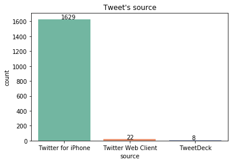

```python
#Visualize the distribution
ax = sns.countplot(x = 'source', data = df,
                   palette="Set2")

#annotate count value on each source
for p, label in zip(ax.patches, df.source.value_counts().values):
    ax.annotate(label, (p.get_x()+0.35, p.get_height()+2.1))

ax.set_title("Tweet's source");
```

### 2.2 Rating distribution

- There are tweet with bad rating, as low as 0.
- Low percentage (< 25 percentile) is with rating < 1.0.
- Majority of rating is between 1 and 1.2. (25 to 75 percentile).
- There is extreme high rating, as high as 7.5

```python
df.rating.describe()
```

```
count    1659.000000
mean        1.087271
std         0.251818
min         0.000000
25%         1.000000
50%         1.100000
75%         1.200000
max         7.500000
Name: rating, dtype: float64
```

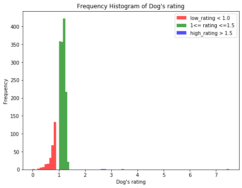

```python
# Divide the rating into 3 category:
# low, medium and high, group as below:
x_low = df.loc[df.rating <=0.99, 'rating']
x_medium = df[(df.rating > 0.99) & (df.rating <=1.5)]['rating']
x_high = df.loc[df.rating >1.5, 'rating']

#kwargs = dict(alpha = 0.8, bins = 15)

# Visualize the dog's rating histogram, with 3 groupings
plt.subplots(figsize = (8,6))
plt.hist(x_low, bins=10, alpha = 0.7, color = 'r', label = 'low_rating < 1.0')
plt.hist(x_medium, bins = 5, alpha = 0.7, color = 'g', label = '1<= rating <=1.5')
plt.hist(x_high, bins=50, alpha = 0.7, color = 'b', label = 'high_rating > 1.5')

plt.gca().set(title = "Frequency Histogram of Dog's rating", ylabel = "Frequency",
              xlabel = "Dog's rating")
plt.legend();
```

### 2.3 Rating versus favorites count for the tweet

- Correlation between rating with like (favorites) counts is low, correlation coefficient of around 0.28.
- From the scatter plot, it was observed, particularly for rating between 1-1.5 region, there is **no** correlation
- For those with extremely high rating, the favorites count is relatively low
- THUS, it shows that, high rating not necessarily well received by audience and receive higher **like**.

```python
# Calculate the Pearson's correlation coefficient
df[['rating','favorites']].corr()
```

|  | rating | favorites |
| --- | --- | --- |
| rating | 1.000000 | 0.288389 |
| favorites | 0.288389 | 1.000000 |

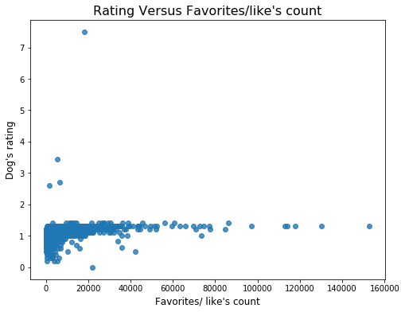

```python
#Visualization on the relationship between Rating and Favorites's count

fig, ax = plt.subplots(figsize = (8,6))

ax.scatter(x = df.favorites, y = df.rating, alpha = 0.8);

plt.title("Rating Versus Favorites/like's count", fontsize = 16)
plt.xlabel("Favorites/ like's count", fontsize=12)
plt.ylabel("Dog's rating", fontsize=12);
```

### 2.4 Retweet versus favourites' count

- Correlation between retweet and favourites' counts is high, correlation coefficient around **0.93**.
- They have strong positive correlation.
- This is logical, as more retweets increase the possibilities to reach out to more users.

```python
# Calculate the Pearson's correlation coefficient
df[['favorites','retweet_count']].corr()
```

|  | favorites | retweet_count |
| --- | --- | --- |
| favorites | 1.000000 | 0.930772 |
| retweet_count | 0.930772 | 1.000000 |

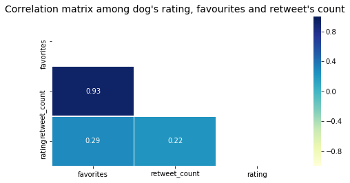

```python
# Get the correlation coefficient on the 3 main numeric variables
data = df[['favorites', 'retweet_count', 'rating']].corr()

# Plot correlation coefficient using heatmap
mask = np.zeros_like(data)
mask[np.triu_indices_from(mask)] = True

fig, ax = plt.subplots(figsize = (8,4))
ax = sns.heatmap(data, mask = mask, vmax = 1, vmin = -1, annot = True,
                linewidths= .5, cmap = 'YlGnBu')
ax.set_title("Correlation matrix among dog's rating, favourites and retweet's count",
            fontsize=14);
```

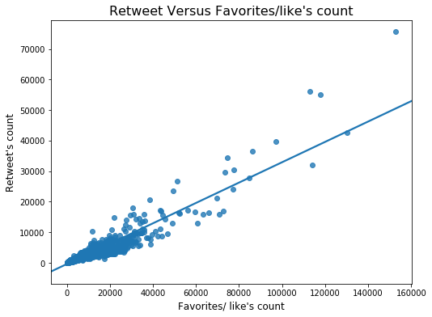

```python
#Visualization on the relationship between Rating and Favorites's count

fig,ax = plt.subplots(figsize=(8,6))

ax = sns.regplot(x = df.favorites, y = df.retweet_count, data = df,
                 robust = False, ci = None)
    # robust = True, fit a robust regression, which uses a different loss function to
    # downweight relatively large residuals

ax.set_xlabel("Favorites/ like's count", fontsize=12)
ax.set_ylabel("Retweet's count", fontsize=12)
ax.set_title("Retweet Versus Favorites/like's count", fontsize = 16);
```

### 2.5 Popular dog's breed

- In total, there are **113** unique dog breed in the tweet data collected.
- Common dog breed is defined by calculating the number of tweet (number of rows) per dog breed, i.e. most common dog breed is with highest number of tweet. **Golden retriever** top the list.
- Popolar dog breed is defined by dog breed that has highest number of favorites count. **Labrado retriever** top the list.
- Strong positive correlation between common breed and total favorites count, r = 0.96. This is logical, as the cummulative favorites count typically higher due to more tweet of the dog breed.
- However, there seems no correlation between total favorites count and mean favorites count, r= 0.31. This means, on average, common breed does not earn higher favorites count.

```python
# Unique number of dog breed
df.dog_breed.nunique()
```

```
113
```

list of dog breed, calculated based on:

```python
# total number tweet per dog breed
common_dog_breed = df.groupby('dog_breed')['favorites'].count()
# average favorites count per dog breed
meanfavorites_dog_breed = df.groupby('dog_breed')['favorites'].mean()
# total favorites count per dog breed
totalfavorites_dog_breed = df.groupby('dog_breed')['favorites'].sum()

# save the calculated data in new dataframe
dog_breed = pd.DataFrame(zip(common_dog_breed, meanfavorites_dog_breed,
                             totalfavorites_dog_breed),
        index = df.groupby('dog_breed')['favorites'].count().index,
        columns =['common_dog_breed',
        'meanfavorites_dog_breed','totalfavorites_dog_breed'])

dog_breed.head()
```

| dog_breed | common_dog_breed | meanfavorites_dog_breed | totalfavorites_dog_breed |
| --- | --- | --- | --- |
| Afghan_hound | 3 | 15438.333333 | 46315 |
| Airedale | 12 | 4719.750000 | 56637 |
| American_staffordshire_terrier | 15 | 7551.200000 | 113268 |
| Appenzeller | 2 | 6549.500000 | 13099 |
| Australian_terrier | 2 | 9979.500000 | 19959 |

Find out the correlation among the calculated field in `dog_breed`

```python
dog_breed.corr()
```

|  | common_dog_breed | meanfavorites_dog_breed | totalfavorites_dog_breed |
| --- | --- | --- | --- |
| common_dog_breed | 1.000000 | 0.164853 | 0.963676 |
| meanfavorites_dog_breed | 0.164853 | 1.000000 | 0.306172 |
| totalfavorites_dog_breed | 0.963676 | 0.306172 | 1.000000 |

Visualize the correlation among the calculated `dog_breed`

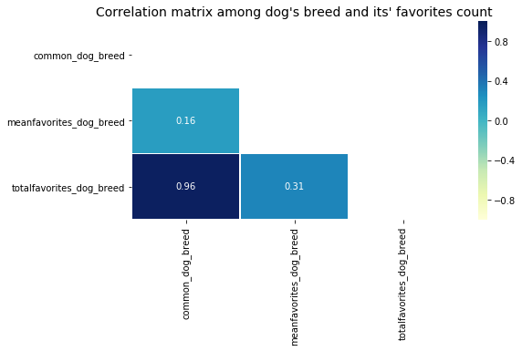

```python
# Plot correlation coefficient using heatmap
data = dog_breed.corr()
mask = np.zeros_like(data)
mask[np.triu_indices_from(mask)] = True

fig, ax = plt.subplots(figsize = (8,4))
ax = sns.heatmap(data, mask = mask, vmax = 1, vmin = -1, annot = True,
                linewidths= .5, cmap = 'YlGnBu')

ax.set_title("Correlation matrix among dog's breed and its' favorites count",
            fontsize=14);
```

```python
def plotbarh(data,title, xlabel, ylabel):
    """
    This function plot horizontal bar plot
    Input: data = list of scalars, values,
    title of the chart,
    xlabel of the char, and ylabel of the chart
    """

    ax = data.plot(kind = 'barh', figsize = (8,6),
                   color = '#86bf91', zorder =2, width = 0.85)
    # Despine
    ax.spines['right'].set_visible(False)
    ax.spines['top'].set_visible(False)
    ax.spines['left'].set_visible(False)
    ax.spines['bottom'].set_visible(False)

    # Draw vertical axis lines
    vals = ax.get_xticks()
    for tick in vals:
        ax.axvline(x=tick, linestyle='dashed',
                   alpha=0.4, color='#eeeeee', zorder=1)

    # set x-axis label
    ax.set_xlabel(xlabel, labelpad=20, size=12);
    # set y-axis label
    ax.set_ylabel(ylabel, labelpad=20, size=12);

    # set the title
    ax.set_title(title, weight='bold', size=16);
```

Visualize the top 10 most commond dog breed

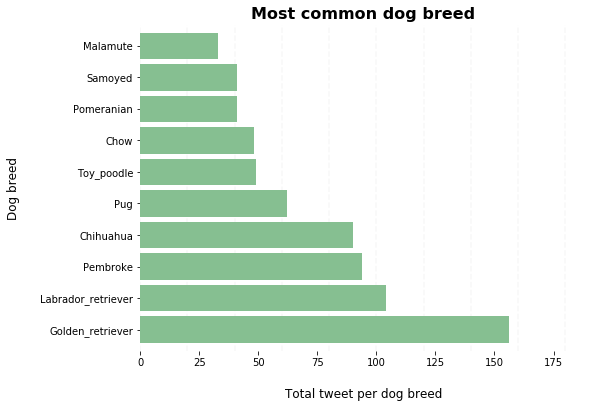

```python
data = df.groupby('dog_breed')['favorites'].count().sort_values(ascending=False)[:10]
title = "Most common dog breed"
xlabel = "Total tweet per dog breed"
ylabel = "Dog breed"
# plot graph using the function `plotbarh(data,title, xlabel, ylabel)`
plotbarh(data,title, xlabel, ylabel)
```

Visualize the top 10 most dog breed with highest number of favorites count

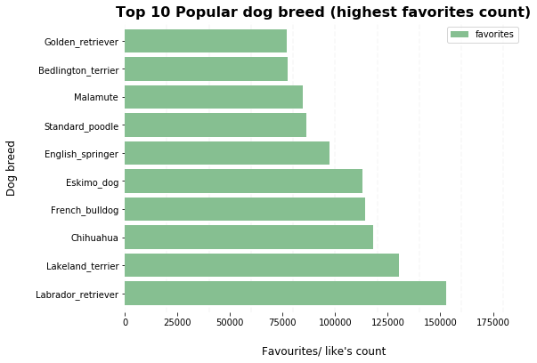

```python
data = df[['dog_breed','favorites']].sort_values(by = 'favorites', \
                ascending= False, ignore_index = True)[:10].set_index('dog_breed')

title = "Top 10 Popular dog breed (highest favorites count)"
xlabel = "Favourites/ like's count"
ylabel = "Dog breed"
# plot graph using the function `plotbarh(data,title, xlabel, ylabel)`
plotbarh(data,title, xlabel, ylabel)
```

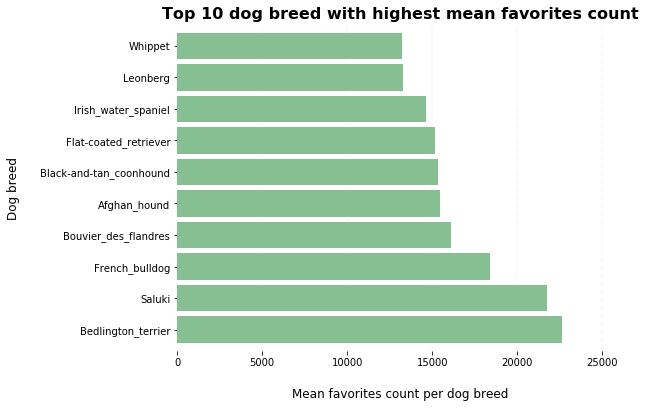

```python
data = df.groupby('dog_breed')['favorites'].mean().sort_values(ascending=False)[:10]
title = "Top 10 dog breed with highest mean favorites count"
xlabel = "Mean favorites count per dog breed"
ylabel = "Dog breed"
# plot graph using the function `plotbarh(data,title, xlabel, ylabel)`
plotbarh(data,title, xlabel, ylabel)
```

### 2.6 Popular dog's stage

```python
# There is only 15% of the tweet with dog stage information
df.dog_stage.value_counts(normalize = True)
```

```
None           0.845690
pupper         0.100663
doggo          0.033153
puppo          0.013261
floofer        0.004822
doggopupper    0.002411
Name: dog_stage, dtype: float64
```

Visualize the distribution of dog stage appeared in the tweet

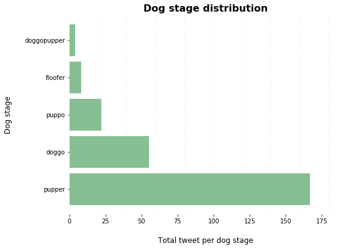

```python
data = df.groupby('dog_stage')['favorites'].count().sort_values(ascending=False)[1:]
title = "Dog stage distribution"
xlabel = "Total tweet per dog stage"
ylabel = "Dog stage"

# plot graph using the function `plotbarh(data,title, xlabel, ylabel)`
plotbarh(data,title, xlabel, ylabel)
```

### 2.7 Tweet day

- **Monday** appeared to be the day with highest total number of tweet.
- **Wednesday** appeared to be the day with highest mean favorites count.

```python
# Count the number of tweet by day of week
df.tweet_day.value_counts(normalize = True)
```

```
Monday       0.168776
Tuesday      0.145268
Thursday     0.145268
Friday       0.142254
Wednesday    0.141652
Sunday       0.133213
Saturday     0.123568
Name: tweet_day, dtype: float64
```

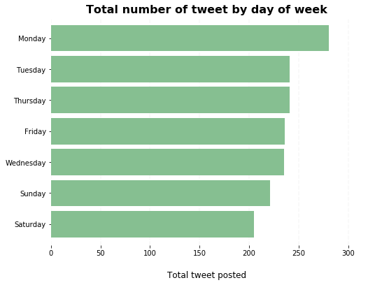

```python
# Visualize the number of tweet by day of week
data = df.groupby('tweet_day')['tweet_id'].count().sort_values(ascending = True)
title = "Total number of tweet by day of week"
xlabel = "Total tweet posted"
ylabel = ""
# plot graph using the function `plotbarh(data,title, xlabel, ylabel)`
plotbarh(data,title, xlabel, ylabel)
```

Visualize the Average number of tweet by day of week

- **Wednesday** top the list
- **Monday** appeared to be the day with 2nd least average favorites count. This shows, in general, more people post their tweet on Monday, and it takes days to collect the **like** by the audience.

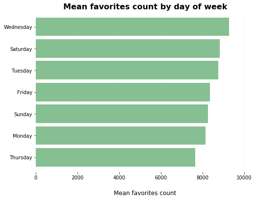

```python
data = df.groupby('tweet_day')['favorites'].mean().sort_values(ascending=True)
title = "Mean favorites count by day of week"
xlabel = "Mean favorites count"
ylabel = ""
# plot graph using the function `plotbarh(data,title, xlabel, ylabel)`
plotbarh(data,title, xlabel, ylabel)
```

### 2.8 Trend of Rating and favorites count over time

- Rating trend increases over time, with tweet's rating typically > 1
- Favorites count increaes over time as it gain popularity

```python
# create another dataframe by setting the index to date (tweet date)
df_time = df.copy()
df_time = df_time[['timestamp','favorites', 'rating',]]

# rename 'timestamp' column to 'date'
df_time.rename(columns = {'timestamp':'date'}, inplace = True)

# set date to index
df_time.set_index('date', inplace = True)
df_time.sort_index(inplace = True)
```

Visualize the Trend of rating and favorites count

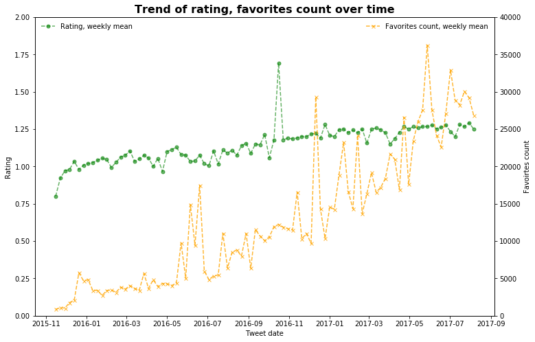

```python
fig, ax = plt.subplots(figsize = (12,8))

# plot the rating trend, using df.resample() group date by week, take weekly mean for rating
ax.plot(df_time['rating'].resample('W').mean(), marker = 'o', markersize = 5,
      linestyle = '--', color = 'g', alpha = 0.6, label = 'Rating, weekly mean')

ax.set_ylabel("Rating")
ax.set_xlabel('Tweet date')
ax.set_ylim(0,2)
ax.legend(loc = 2, frameon = False);

# plot favorites count trend in the same plot
ax2 = ax.twinx()

ax2.plot(df_time['favorites'].resample('W').mean(), marker = 'x', markersize = 5,
      linestyle = '--', color = 'orange', alpha = 0.8, label = 'Favorites count, weekly mean')
ax2.legend(loc = 1, frameon = False)
ax2.set_ylabel("Favoirtes count")
ax2.set_ylim(0,40000)
ax.set_title("Trend of rating, favorites count over time", weight = 'bold', size = 16);
```

### 2.9 Top rating dog

- It is Pomeranian dog, name Logan

```python
# Get the row number of dog with highest rating
toprate_idx_val = df.sort_values(by = ['rating'], ascending = False)[:1].index.values[0]
```

```python
# Display the tweet data on dog with highest rating
df.loc[toprate_idx_val]
```

[output not shown]

```python
# Text of tweet
df.loc[toprate_idx_val, 'text']
```

```
"This is Logan, the Chow who lived. He solemnly swears he's up to lots of good. H*ckin magical af 9.75/10 https://t.co/yBO5wuqaPS"
```

This is the link to the top rate dog: [expanded_urls](https://twitter.com/dog_rates/status/786709082849828864/photo/1)

[figure not shown]

```python
from IPython.display import Image
Image(filename='./photo/top_rate.jpeg')
```

### 2.10 Most popular dog

- It is Labrador_retriever, a doggo.

```python
# Get the row number of dog that has highest favorites count
popular_idx_val = df.sort_values(by = ['favorites'], ascending = False)[:1].index.values[0]
```

```python
# Display the tweet with highest favorites count
df.loc[popular_idx_val]
```

[output not shown]

```python
#Tweet text
df.loc[popular_idx_val, 'text']
```

```
"Here's a doggo realizing you can stand in a pool. 13/10 enlightened af (vid by Tina Conrad) https://t.co/7wE9LTEXC4"
```

This is the link to the most popular doggo: [expanded_urls_video](https://twitter.com/dog_rates/status/744234799360020481/video/1)

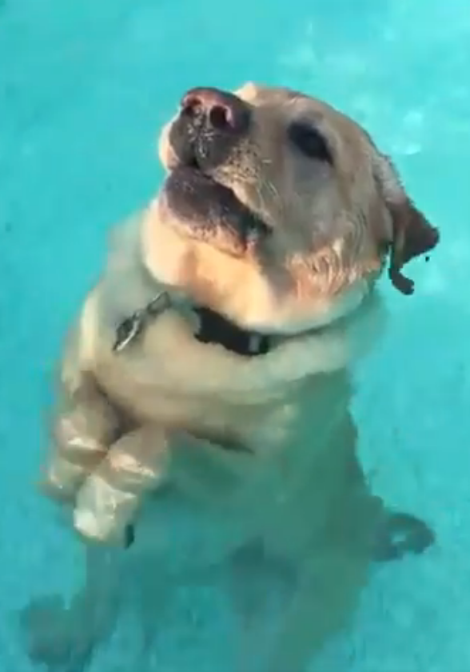

```python
from IPython.display import Image
Image(filename='./photo/popular_doggo.png')
```

# 3 Summary and conclusion

**Summary**

I am not able to gather user's data that push the tweet. The JSON data obtained is with only ONE user's ID. Else, it will be interesting to find out information like average tweet per user, any correlation betwen favorites count and number of followers, number of friends of the user. Any correlation between tweet's favorites count and the user's total favorites count, correlation between tweet's favorites count and number of tweet push by the user.

**Conclusion**  
I would like to conclude by listing down what I have learnt in this project:

- Programmatically download file from html using the `Requests` library.
- Setup up Twitter's Developer account and query twitter data using `Tweepy`.
- Writing and reading Twitter JSON data.
- Data wrangling by gathering data from various sources, assessing data to detect data quality issues and data tidiness issues, and cleaning data.